# Lab: Gradient Boosting

Hicham Zmarrou

2018-03-06

## Preparation of Data for using XGBoost

`XGBoost` only works with numeric vectors. Yes! you need to work on data types here.

Therefore, you need to convert all other forms of data into numeric vectors. A simple method to convert categorical variable into numeric vector is One Hot Encoding. This term emanates from digital circuit language, where it means an array of binary signals and only legal values are 0s and 1s.

In `R`, one hot encoding is quite easy. This step (shown below) will essentially make a sparse matrix using flags on every possible value of that variable. Sparse Matrix is a matrix where most of the values of zeros. Conversely, a dense matrix is a matrix where most of the values are non-zeros.

## Building Model using Xgboost on R

### Step 1: Load all the libraries

```r
suppressMessages(library(xgboost))
suppressMessages(library(readr))
suppressMessages(library(stringr))
suppressMessages(library(caret))
suppressMessages(library(car))
```

### Step 2: Load the dataset

Load the data: The data from the Loan Prediction Challenge. You can download them from here: [train](https://drive.google.com/file/d/0B4wfKzAJl58HSHhUWF9zX0RfcEk/view?usp=sharing), [test](https://drive.google.com/file/d/0B4wfKzAJl58HUkxuTlRUZm9nbFE/view?usp=sharing).

```r
set.seed(100)
df_train = read_csv("./data/train_users_2.csv")
df_test = read_csv("./data/test_users.csv")
```

#### Load labels of the train data

```r
labels = df_train['Loan_Status']
df_train = df_train[-grep('Loan_Status', colnames(df_train))]
# Combine train and test data
df_all = rbind(df_train,df_test)
```

### Step3: Data Cleaning & Feature Engineering

The main purpose here is to deal with all the missing variables in the data. And also, creat dummy variable for the categorical features. (The missing value imputation here is arbitrary, without any validity.)

```r
df_all$Gender[is.na(df_all$Gender)] = "Male"
df_all$Married[is.na(df_all$Married)] = "No"
df_all$Self_Employed[is.na(df_all$Self_Employed)] = "No"
df_all$LoanAmount[is.na(df_all$LoanAmount)] = mean(df_all$LoanAmount, na.rm = TRUE)
df_all$Loan_Amount_Term[is.na(df_all$Loan_Amount_Term)] = 360
df_all$Credit_History[is.na(df_all$Credit_History)] = 1
df_all$Dependents[is.na(df_all$Dependents)] = 0
```

One-hot-encoding categorical features

```r
ohe_feats = c("Gender", "Married", "Education", "Self_Employed", "Property_Area")
dummies <- dummyVars(~ Gender + Married + Education + Self_Employed + Property_Area, data = df_all)
df_all_ohe <- as.data.frame(predict(dummies, newdata = df_all))
df_all_combined <- cbind(df_all[,-c(which(colnames(df_all) %in% ohe_feats))],df_all_ohe)
```

Split train and test data set

```r
X = df_all_combined[df_all_combined$Loan_ID %in% df_train$Loan_ID,]
y <- recode(labels$Loan_Status,"'Y'=1; 'N'=0")
X_test = df_all_combined[df_all_combined$Loan_ID %in% df_test$Loan_ID,]
```

### Step 4: Tune and Run the model

```r
set.seed(100)
xgb <- xgboost(data = data.matrix(X[,-1]),
 label = y,
 eta = 0.1,
 max_depth = 15,
 nround=25,
 subsample = 0.5,
 colsample_bytree = 0.5,
 eval_metric = "merror",
 objective = "multi:softprob",
 num_class = 12,
 nthread = 3
)
```

```
NAs introduced by coercion
```

### Step 5: Score the Test

```r
y_pred <- predict(xgb, data.matrix(X_test[,-1]))
```

```
NAs introduced by coercion
```

### Step 6: Check the model

Prints top 10 nodes of the model

```r
model <- xgb.dump(xgb, with_stats = T)
model[1:10]
```

```
 [1] "booster[0]"                                                         "0:[f8<0.5] yes=1,no=2,missing=1,gain=4.65142,cover=45.375"
 [3] "1:[f1<6866.5] yes=3,no=4,missing=3,gain=6.30734,cover=28.7222"      "3:[f15<0.5] yes=7,no=8,missing=7,gain=5.44143,cover=24.1389"
 [5] "7:[f1<3524.5] yes=13,no=14,missing=13,gain=6.08646,cover=13.75"     "13:[f1<2980] yes=21,no=22,missing=21,gain=5.50594,cover=6.41667"
 [7] "21:leaf=0.156923,cover=3.51389"                                     "22:[f1<3299.5] yes=29,no=30,missing=29,gain=0.349645,cover=2.90278"
 [9] "29:leaf=-0.0352941,cover=1.83333"                                   "30:leaf=0.0201342,cover=1.06944"
```

Compute feature importance matrix

```r
names <- dimnames(data.matrix(X[,-1]))[[2]]
```

```
NAs introduced by coercion
```

```r
importance_matrix <- xgb.importance(names, model = xgb)
importance_matrix
```

| Feature | Gain | Cover | Frequency |
| --- | --- | --- | --- |
| Credit_History | 0.3058161666 | 0.104456438 | 0.020360219 |
| LoanAmount | 0.2104296249 | 0.267056177 | 0.339859045 |
| ApplicantIncome | 0.1791261522 | 0.182393799 | 0.227094753 |
| CoapplicantIncome | 0.0932433405 | 0.133663349 | 0.109631950 |
| Dependents | 0.0291289079 | 0.038993461 | 0.043069695 |
| Property_AreaSemiurban | 0.0272372279 | 0.025401980 | 0.026624902 |
| Property_AreaRural | 0.0267236181 | 0.042077534 | 0.038371182 |
| Loan_Amount_Term | 0.0247335700 | 0.035201793 | 0.018794049 |
| MarriedNo | 0.0212416684 | 0.033729450 | 0.025058731 |
| EducationGraduate | 0.0204917762 | 0.034707658 | 0.028974158 |

[output cut: 7 more lines]

Generate the imporance graph

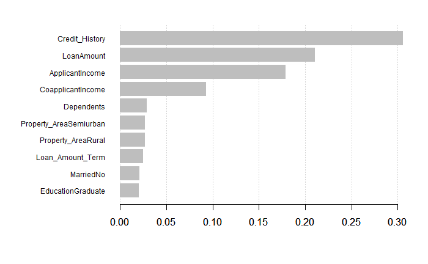

```r
xgb.plot.importance(importance_matrix[1:10,])
```